# Clase 01

```
## Linked to JAGS 4.2.0
```

```
## Loaded modules: basemod,bugs
```

**Ejercicio 1. NotasL15L2.pdf pag 37.**

*Sea $\theta$ la tasa de créditos hipotecarios otorgados por un banco. Durante el 2004 la tasa promedio fue de 60% y la desviación estándar de la tasa fue de 0.04. En lo que va del año 2005 se han solicitado 100 créditos, de los cuales se han otorgado únicamente 50.*

*a) Usando la información del año pasado encuentra la distribución beta que mejor describe el conocimiento inicial.*

Con la información del problema sabemos que $E(X) = 0.6$ y $\sqrt{Var(X)} = 0.04$. Sea X una distribución $Beta(\alpha, \beta)$, $E(X) = \frac{\alpha}{\alpha + \beta}$ y $Var(X) = \frac{\alpha\beta}{(\alpha + \beta)^2 (\alpha + \beta + 1)}$.

Entonces… si contara con el tiempo y la paciencia necesaria para hacer esto, despejaría para $\alpha$ y $\beta$ y llegaría al resultado que $\alpha = 89.4$ y $\beta = 59.6$. La cual se ve así.

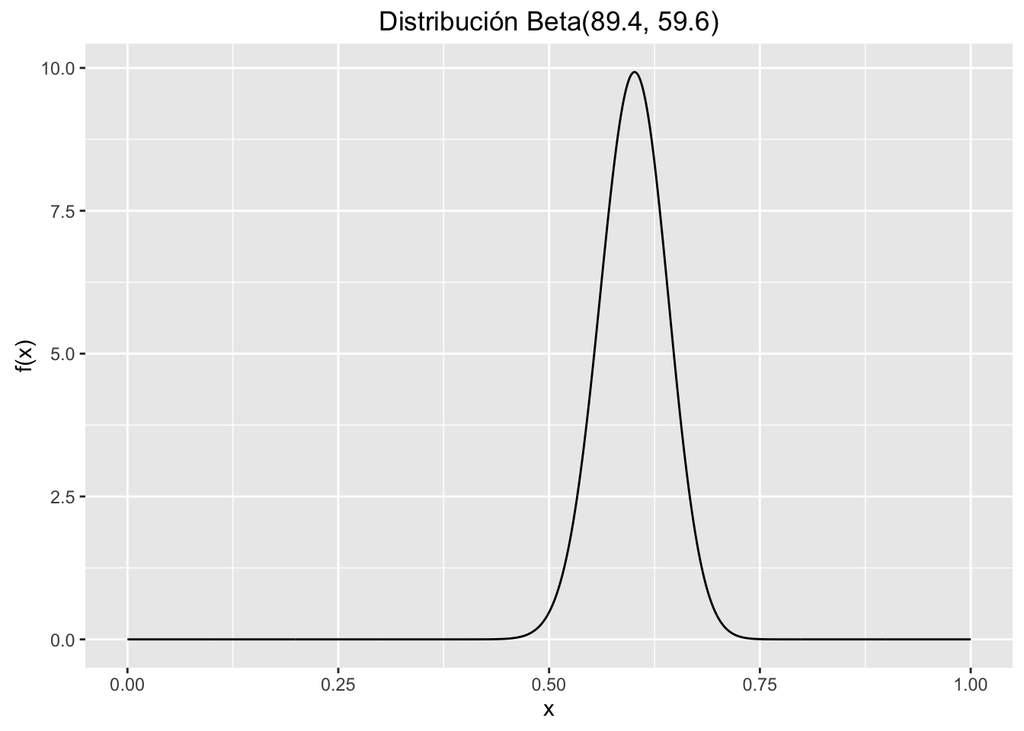

*b) Usando la información del año pasado, encuentra la distribución normal transformada que mejor describa el conocimiento inicial.*

De manera similar al inciso *a*, Sea $X \sim LogN(\mu, \sigma^2)$ entonces $E(X) = e^{(\mu + \frac{\sigma^2}{2})}$ y $Var(X) = (e^{\sigma^2} - 1)e^{2\mu + \sigma^2}$. … Si contara con la energía vital suficiente para realizar esto como se debe hacer llegaría a que los parámetros son: $\mu = .4054$ y $\sigma^2 = 33.33$, la cual se ve así:

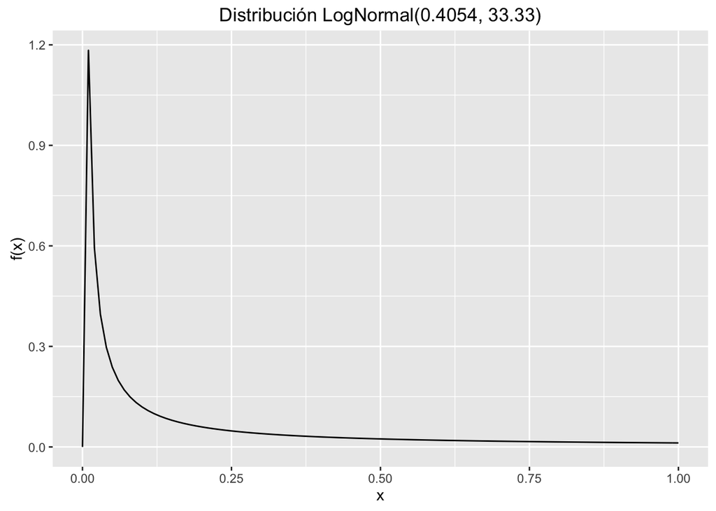

*c) Determina la distribución inicial de referencia.*

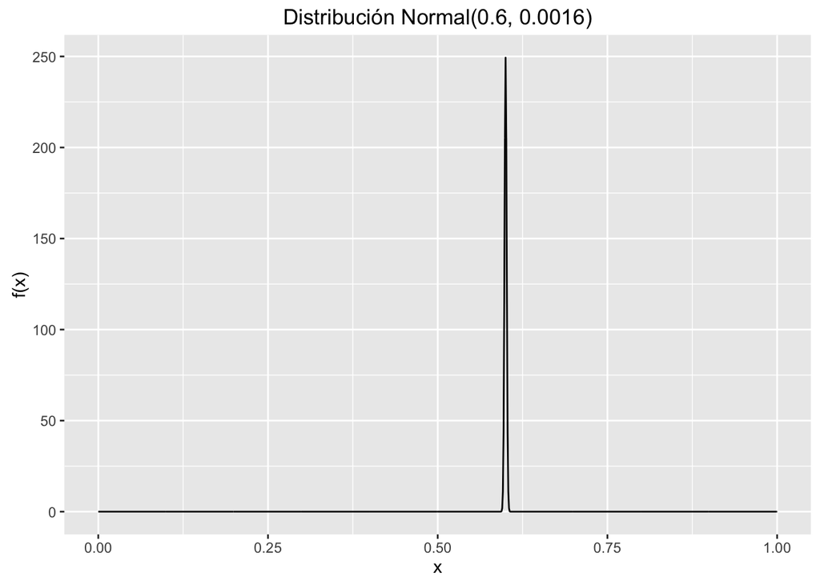

*d) Usando los datos del año 2005 encuentra la distribución final para cada una de las distribuciones iniciales de los incisos a - c.*

Utilizamos JAGS en R para implementar esta solución. La solución para cada inciso es distinta dependiendo de la distribución apriori que asignemos.

Para el inciso *a*: $Beta(89.4, 59.6)$:

```r
# Generamos los datos de la muestra y los guardamos en una lista
n <- 100
credito <- c(rep(1, 50), rep(0, 50))
data <- list("n" = n, "x" = credito)
inits <- function(){list(theta = 0.5, x1 = rep(1, 2))}

# Seleccionamos los parámetros que queremos monitorear
parameters <- c("theta","x1")

ej1.sim <- jags(data, inits, parameters, model.file = "Ej1_a.txt",
                n.iter = 5000, n.chains = 1, n.burnin = 500,
                working.directory = "src/")
```

```
## module glm loaded
```

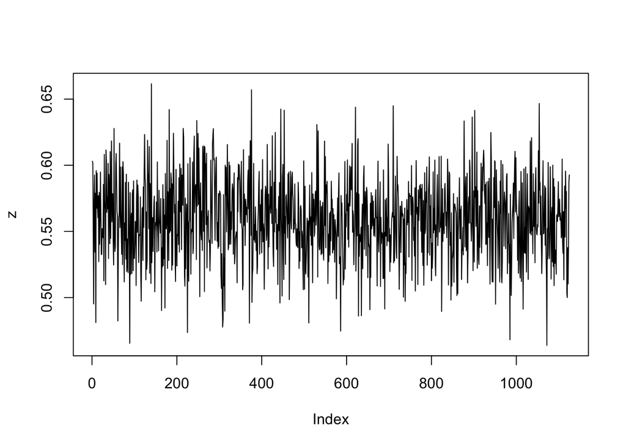

```r
# Monitoreo
out <- ej1.sim$BUGSoutput$sims.list
z <- out$theta
plot(z, type = "l")
```

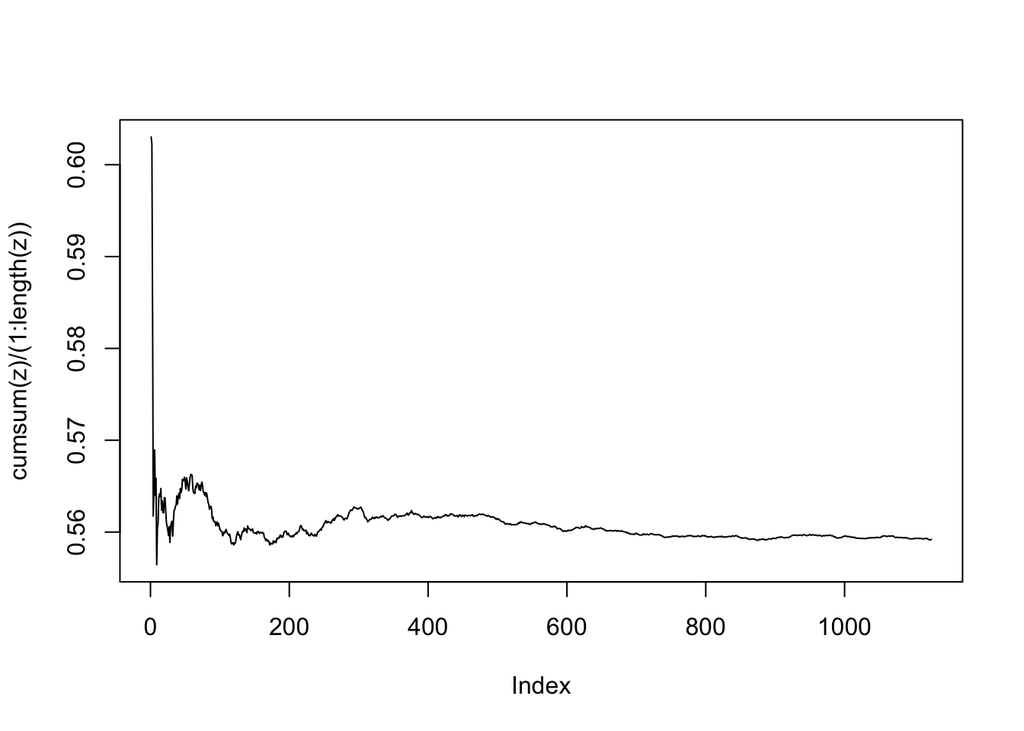

```r
plot(cumsum(z)/(1:length(z)), type = "l")
```

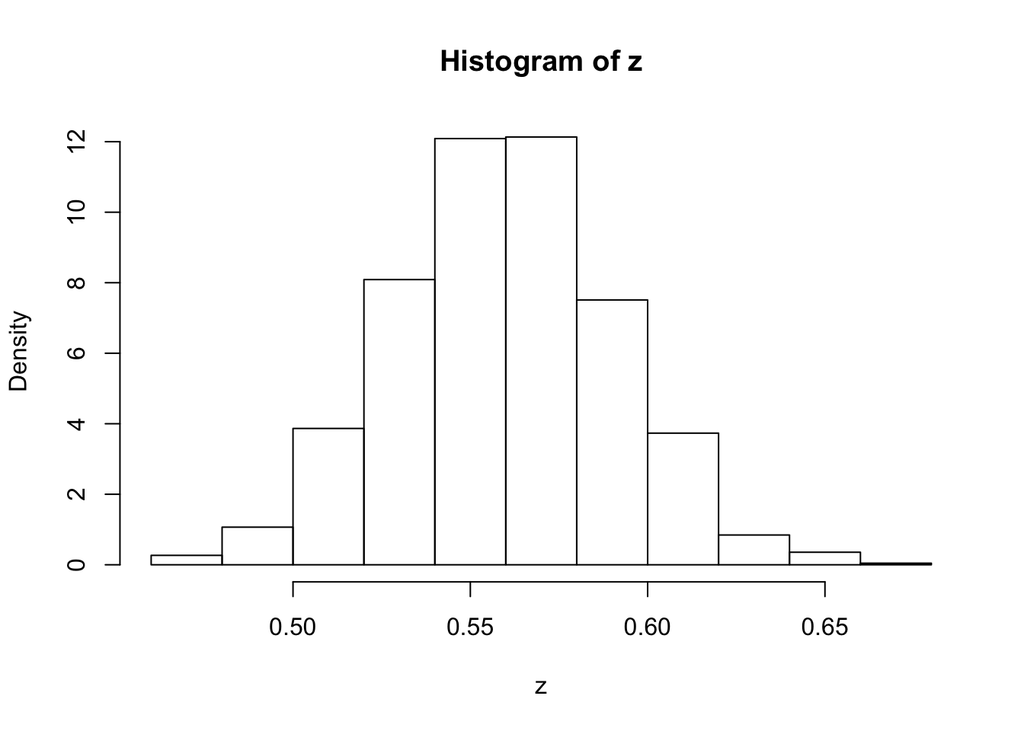

```r
hist(z, freq=FALSE)
```

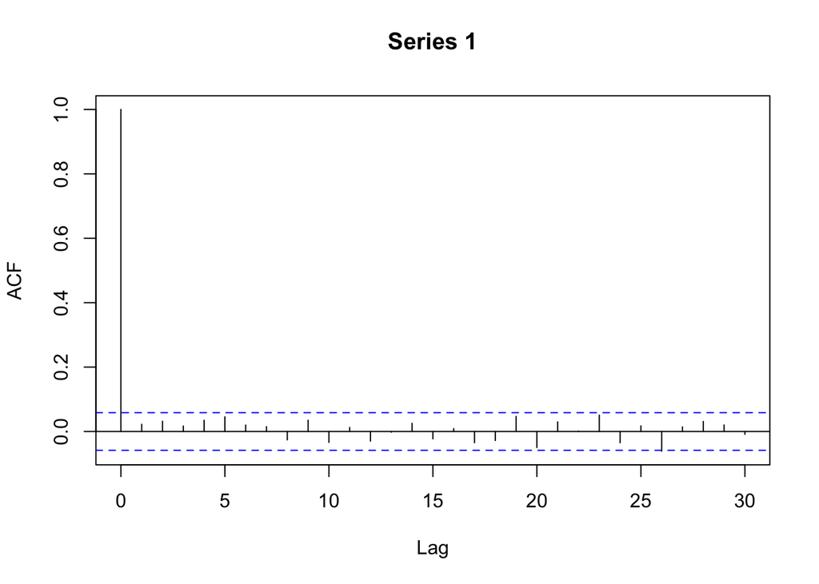

```r
acf(z)
```

```r
out.sum <- ej1.sim$BUGSoutput$summary
print(out.sum)
```

```
##                 mean         sd        2.5%         25%         50%
## deviance 140.4464201 1.62304743 138.6576085 139.2187595 140.0269063
## theta      0.5591964 0.03108112   0.4985104   0.5383272   0.5589014
## x1[1]      0.5706667 0.49520117   0.0000000   0.0000000   1.0000000
## x1[2]      0.5742222 0.49468028   0.0000000   0.0000000   1.0000000
##                  75%       97.5%
## deviance 141.2205203 144.4493027
## theta      0.5799657   0.6188881
## x1[1]      1.0000000   1.0000000
## x1[2]      1.0000000   1.0000000
```

```r
out.dic <- ej1.sim$BUGSoutput$DIC
out.dic
```

```
## [1] 141.7636
```